# ICY0006 - Probability Theory and Statistics - Matryg project, TalTech

# Stage 1

## Introduction

This is my project for the course ICY0006 - Probability Theory and Statistics at TalTech University.  
Among the content of my project is a matryg_Notebook.Rmd-file and from that file a html-file can be generated and read as a report. Any questions related to the report can be sent to my mail: matryg@ttu.ee  
The link to my GitHub repo is https://github.com/matry18/matrygV3  
Enjoy the reading!

## The work environment

For this project I have used RStudio as my IDE. I have used version control with Git and continuously committed my work to GitHub, where the repository is public accessible.  
I have used the Notebook function in RStudio to generate the matryg_Notebook.Rmd-file from where a .html-file was generated and can be read as the report for this project.  
The development of the report was an ongoing process following the progression of the course and continuous implementing the topics taught in the lecture and practices.

## The dataset

The original dataset for this project was based on house prices and computer generated. This caused some issues since the dataset was not suitable due to a certain problem. Because of that the dataset was changed 4 weeks into the course. Doing the 8th week of the course I faced some problems with all the possible linear regressions in the dataset being heteroscedastic. This lead to another change of the dataset. Therefore this dataset is version 3 in my project.

This dataset is about lung capacity and is public available at https://www.kaggle.com/aakashmisra/lung-capacity with an unknown (public) license. The version of the dataset is version 1 and was created the 28/9 2020 by the user Aakash Misra - https://www.kaggle.com/aakashmisra  
The dataset is a .csv-file and I downloaded it and unzipped it before importing it. When doing the importing of the dataset I used a dynamic file.choose() method where I chose the downloaded and unzipped file.

```r
data1 <- read.csv(file.choose(), header=TRUE)
View(data1)
attach(data1)
```

To be able to manipulate and visualize the data set the following libraries and dependencies was loaded.

```r
##Data Manipulation
library(tidyverse)
library(psych)
library(lubridate)
library(xts)
library(tseries)
library(forecast)
library(MLmetrics)
library(MASS)
library(caTools)
#Visualisation
library(corrplot)
library(plotly)
library(viridis)
library(ggmap)
library(knitr)
library(dygraphs)
library(ggthemes)
library(reshape)
library(reshape2)
library(ggplot2)
library(ggcorrplot)
library(ggstatsplot)
```

## Variables

In the following I will describe the variables in the data set.  
The data set consists of 725 observations and has 6 variables.

**LungCap** is short for lung capacity also know as total lung capacity (TLC). Lung capacity is the volume of air in the lungs upon the maximum effort of inspiration. Among healthy adults, the average lung capacity is about 6 liters. Age, gender, body composition, and ethnicity are factors affecting the different ranges of lung capacity among individuals. TLC rapid increases from birth to adolescence and plateaus at around 25 years old. Males tend to have a greater TLC than females, while individuals with tall stature tend to have greater TLC than those with short stature, and individuals with a high waist-to-hip ratio generally have a lower TLC. Individuals of African descent have a lower TLC compared to individuals of European descent. Additional factors that affect an individual’s lung capacity include the level of physical activity, chest wall deformities, and respiratory diseases.[^1]  
The lung capacity is a dependent variable since it is influenced by age, gender etc. It is a continuous value as well as quantitative. It is measured on an interval scale.

**Age** indicates the persons age in years. This variable is independent, quantitative and discrete since all the age values are presented as integer values on an interval scale.

**Height** is the height in inches. This is an independent, continuous, quantitative variable measured on an interval scale. This variable must be transformed into a measurement of meter. Therefore I multiply the height value with 0.0254 to get the value in meter. This value has been added to the dataset as the variable **HeightMeter** and share the same characteristics as Height.

```r
data1[,3]*0.0254
```

[output not shown]

[output cut: 34 more lines]

The **Smoke** variable is independent, discrete and qualitative. It defines if the person is smoking, since it influences the lung capacity. The categorical values is “yes” if the person smokes and “no” if the person does not smoke. This is measured on a nominal scale. As an alternative the true/false-value could have been indicated with numbers, where 1 is true and 0 is false, but for now I will not manipulate the value.

**Gender** defines the gender of the person. This variable is independent, discrete and qualitative measured on a nominal scale. If the person is male the value is “male” and if the person is female the value is “female”. As an alternative the true/false-value could have been indicated with numbers, where 1 is true and 0 is false, but for now I will not manipulate the value.

The **Caesarean** indicates how the person was born. If the person was born by caesarean the value is “yes” and if not the value is “no”. This is an independent, discrete, qualitative variable measured on a nominal scale. As an alternative the true/false-value could have been indicated with numbers, where 1 is true and 0 is false, but for now I will not manipulate the value.

### Missing data

Before going any further with the dataset I will check for any missing values by the use of the inbuilt function in RStudio.

```r
which(is.na(data1))
```

```
integer(0)
```

Since the returned value is zero that means that I don’t have any missing data in my dataset.

### Data visualization

In the following I will visualize each variable. For Lung capacity, age and height in meters I have used histograms. Since histograms are strongly affected by the number of bins and therefore makes it difficult to determine the shape of the distribution I have added a normal curve to the histograms.  
Another way of viewing the variables could be with the use of Kernel Density plots. Therefore I have chosen to visualize the lung capacity, age and height in meters with this curve.  
**Lung capacity**

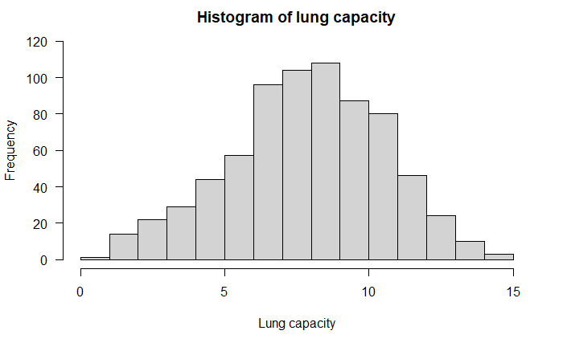

```r
hist(data1$LungCap, las=1, ylim= c(0,120),xlab = "Lung capacity", main= "Histogram of lung capacity")
```

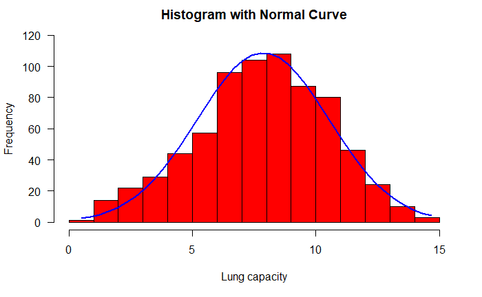

```r
x <- data1$LungCap
h<-hist(x, breaks=20, col="red", xlab="Lung capacity", las=1, main="Histogram with Normal Curve", ylim = c(0,120), xlim = c(0,15))
xfit<-seq(min(x),max(x),length=40)
yfit<-dnorm(xfit,mean=mean(x),sd=sd(x))
yfit <- yfit*diff(h$mids[1:2])*length(x)
lines(xfit, yfit, col="blue", lwd=2)
```

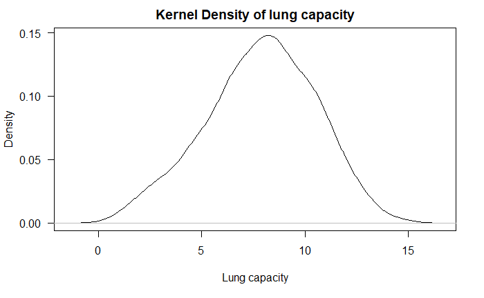

```r
plot(density(data1$LungCap), main = "Kernel Density of lung capacity", xlab = "Lung capacity", las=1)
```

**Age**

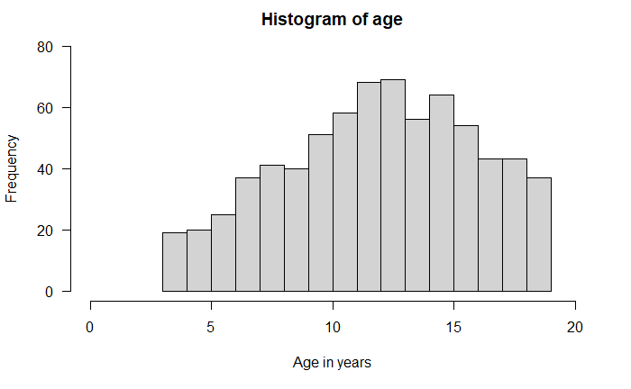

```r
hist(data1$Age, xlim = c(0,20), ylim=c(0,80), las=1, xlab = "Age in years", main= "Histogram of age", breaks = 20)
```

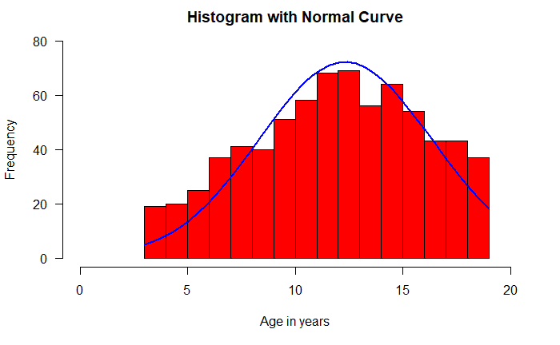

```r
x <- data1$Age
h<-hist(x, breaks=20, col="red", xlab="Age in years", las=1, main="Histogram with Normal Curve", ylim = c(0,80), xlim = c(0,20))
xfit<-seq(min(x),max(x),length=40)
yfit<-dnorm(xfit,mean=mean(x),sd=sd(x))
yfit <- yfit*diff(h$mids[1:2])*length(x)
lines(xfit, yfit, col="blue", lwd=2)
```

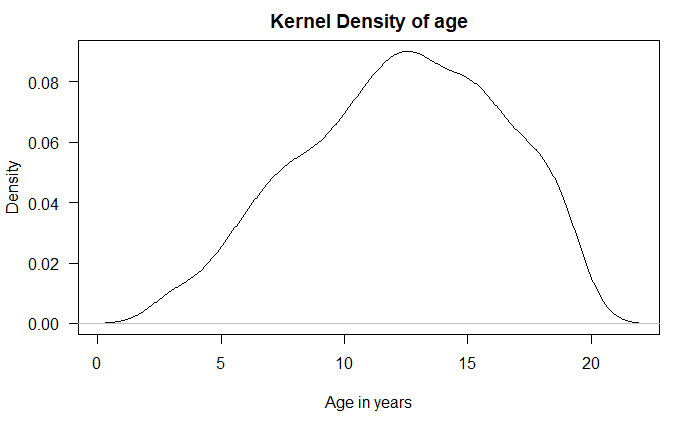

```r
plot(density(data1$Age), main = "Kernel Density of age", xlab = "Age in years", las=1)
```

**Height in meters**

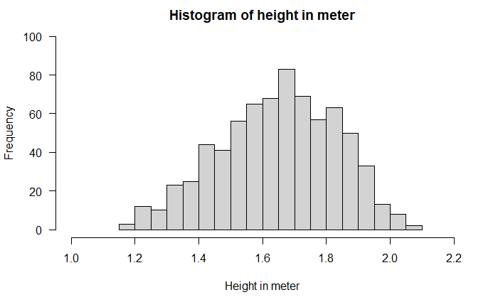

```r
hist(data1$HeightMeter, xlim= c(1,2.2), ylim = c(0,100), las=1, xlab = "Height in meter", main= "Histogram of height in meter", breaks = 20)
```

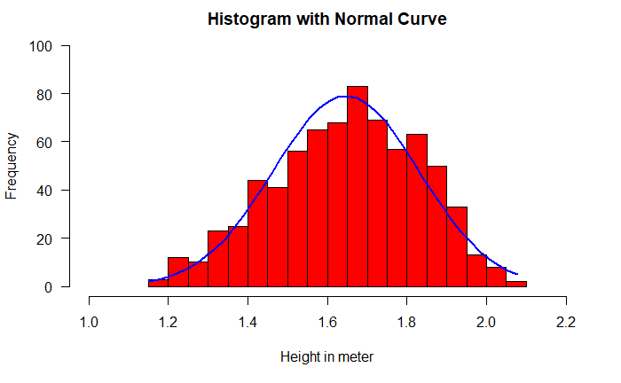

```r
x <- data1$HeightMeter
h<-hist(x, breaks=20, col="red", xlab="Height in meter", las=1, main="Histogram with Normal Curve", ylim = c(0,100), xlim = c(1,2.2))
xfit<-seq(min(x),max(x),length=40)
yfit<-dnorm(xfit,mean=mean(x),sd=sd(x))
yfit <- yfit*diff(h$mids[1:2])*length(x)
lines(xfit, yfit, col="blue", lwd=2)
```

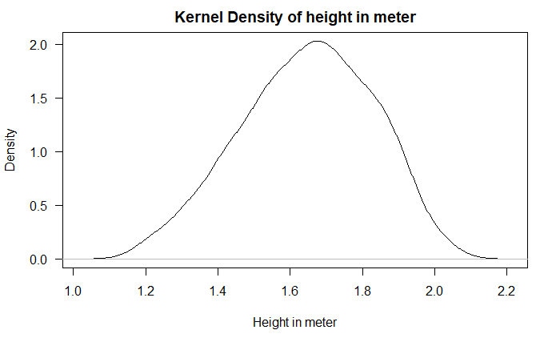

```r
plot(density(data1$HeightMeter), main = "Kernel Density of height in meter", xlab = "Height in meter", las=1)
```

In the following I will visualize the categorical variables with pie charts since it makes a good overview.

**Smoke**

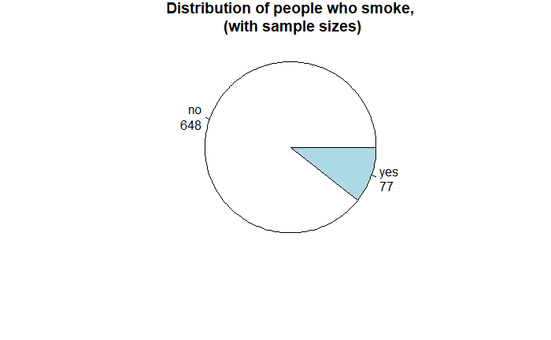

```r
smoke.count<-table(data1$Smoke)
lbls <- paste(names(smoke.count), "\n", smoke.count, sep="")
pie(smoke.count,border=T, labels = lbls,
   main="Distribution of people who smoke,\n (with sample sizes)")
```

**Gender**

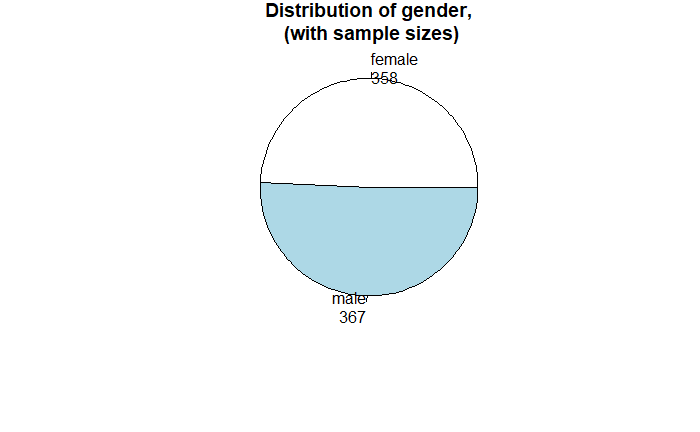

```r
gender.count<-table(data1$Gender)
lbls <- paste(names(gender.count), "\n", gender.count, sep="")
pie(gender.count,border=T, labels = lbls,
   main="Distribution of gender,\n (with sample sizes)")
```

**Caesarean**

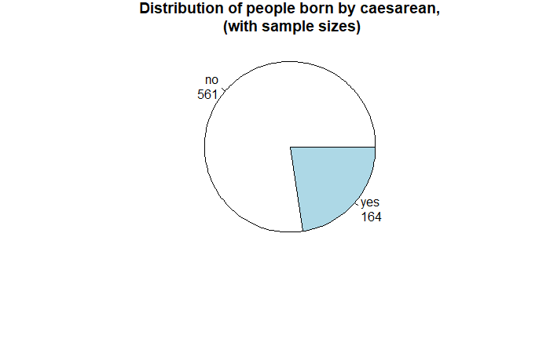

```r
caesarean.count<-table(data1$Caesarean)
lbls <- paste(names(caesarean.count), "\n", caesarean.count, sep="")
pie(caesarean.count,border=T, labels = lbls,
   main="Distribution of people born by caesarean,\n (with sample sizes)")
```

### Interpreting the visualization

In the following I will describe what can be seen from the graphs and charts.

The lung capacity has a nice bell shape, which indicates a normal distribution. The distribution is very close to be complete symmetrical with a single peek.  
The age variable is close of having a nice bell shape but it tends to have a small negative skewness. It has a single peek and is close to being symmetrical but not complete symmetrical.  
The height in meter has a very nice bell shape which indicates a normal distribution with a single peek and the shape of it is very close to be symmetrical.  
The distribution of people who smoke indicates that approx. 1/8 of the people in the population do smoke and 7/8 does not.  
The distribution of genders is close to be even with slightly more males than females in the population.  
The distribution of people born by ceasarean shows that nearly 1/4 of the population is born by caesarean and 3/4 is not.

# Stage 2

## Quantitative overview of data

In the following I will compute the central tendency, also known as measure of central tendency or average. Basically this is the central value for a probability distribution. I will also compute the variability measures which is how “spread out” the data is. Then I will do a short analysis of the central tendencies and variability measures and compare the outcome with the visual representation of the distributions.

### Central tendency measures

#### Mean, trimmed mean, median and mode

The mean is the sum of numerical values of each observation divided by the total number of observations, or put in a simpler way the sum of numbers divided by the number of numbers. The mean indicates at what point the distribution is in balance. In the following you will see the population mean for lung capacity, age and height in meters.

**Lung capacity mean**

```r
lungCap.mean <- mean(data1$LungCap)
print(lungCap.mean)
```

```
[1] 7.863148
```

**Age mean**

```r
age.mean <- mean(data1$Age)
print(age.mean)
```

```
[1] 12.3269
```

Since the age variable is discrete I will have to round off the mean value to not have a decimal number.

```r
print(round(age.mean))
```

```
[1] 12
```

**Height in meters mean**

```r
heightMeter.mean <- mean(data1$HeightMeter)
print(heightMeter.mean)
```

```
[1] 1.646841
```

**Lung capacity trimmed mean of 20 %**

```r
mean(data1$LungCap, trim = 0.2)
```

```
[1] 7.979425
```

**Age trimmed mean of 20 %**

```r
mean(data1$Age, trim = 0.2)
```

```
[1] 12.52874
```

And since age is a discrete variable it will have to be rounded off.

```r
round(mean(data1$Age, trim = 0.2))
```

```
[1] 13
```

**Height in meter trimmed mean of 20 %**

```r
mean(data1$HeightMeter, trim = 0.2)
```

```
[1] 1.654264
```

The median is the 50th percentile of the distribution which is the same as the value in the exact middle of the distribution. If the distribution is a even number, then I will take the average of the middle two values. The median can be found with the summary-function i R.

```r
summary(data1)
```

```
    LungCap            Age            Height         Smoke              Gender           Caesarean          HeightMeter
 Min.   : 0.507   Min.   : 3.00   Min.   :45.30   Length:725         Length:725         Length:725         Min.   :1.151
 1st Qu.: 6.150   1st Qu.: 9.00   1st Qu.:59.90   Class :character   Class :character   Class :character   1st Qu.:1.521
 Median : 8.000   Median :13.00   Median :65.40   Mode  :character   Mode  :character   Mode  :character   Median :1.661
 Mean   : 7.863   Mean   :12.33   Mean   :64.84                                                            Mean   :1.647
 3rd Qu.: 9.800   3rd Qu.:15.00   3rd Qu.:70.30                                                            3rd Qu.:1.786
 Max.   :14.675   Max.   :19.00   Max.   :81.80                                                            Max.   :2.078
```

This shows the median for **lung capacity** is 8.0, for **age** it is 13.0 and for **height in meter** it is 1.661.

The mode is the most frequent value in the distribution for a given variable. To compute the mode I use a function.

```r
getmode <- function(v) {
  uniqv <- unique(v)
  uniqv[which.max(tabulate(match(v, uniqv)))]
}
lungCap.mode <- getmode(data1$LungCap)
print(lungCap.mode)
```

```
[1] 8.35
```

**Mode lung capacity**

```r
lungCap.mode <- getmode(data1$LungCap)
print(lungCap.mode)
```

```
[1] 8.35
```

**Mode age**

```r
age.mode <- getmode(data1$Age)
print(age.mode)
```

```
[1] 13
```

**Mode height in meter**

```r
heightMeter.mode <- getmode(data1$HeightMeter)
print(heightMeter.mode)
```

```
[1] 1.66116
```

### Variability measures

#### Range & interquartile range

The range of an observation variable is the difference of its largest and smallest data values. It is a measure of how far apart the entire data spreads in value.

**Lung capacity range**

```r
print(range(data1$LungCap))
```

```
[1]  0.507 14.675
```

**Age range**

```r
print(range(data1$Age))
```

```
[1]  3 19
```

**Height in meter range**

```r
print(range(data1$HeightMeter))
```

```
[1] 1.15062 2.07772
```

The interquartile range (IQR) of an observation variable is the difference of its upper and lower quartiles. It is a measure of how far apart the middle portion of data spreads in value. In other words it is the range of the middle 50 % of the scores in a distribution.

**Lung capacity IQR**

```r
IQR(data1$LungCap)
```

```
[1] 3.65
```

**Age IQR**

```r
IQR(data1$Age)
```

```
[1] 6
```

**Height in meter IQR**

```r
IQR(data1$HeightMeter)
```

```
[1] 0.26416
```

#### Variance & Standard Deviation

**Lung capacity variance**

```r
print(var(data1$LungCap))
```

```
[1] 7.086288
```

**Age variance**

```r
print(var(data1$Age))
```

```
[1] 16.03802
```

The variance produces a measures of how far a set of numbers is spread out from their average value. Since age is a discrete value it has to be rounded off.

```r
print(round(var(data1$Age)))
```

```
[1] 16
```

**Height in meter variance**

```r
print(var(data1$HeightMeter))
```

```
[1] 0.03346502
```

The standard deviation (SD) of an observation variable is the square root of its variance. This is a useful measure of variability when the distribution is normal (or close to) because the proportion of the distribution within a given number of standard deviations from the mean can be calculated. Put in a more simple way, the SD can be used to measure the spread of the data in relation to the mean.

**Lung capacity SD**

```r
print(sd(data1$LungCap))
```

```
[1] 2.662008
```

**Age SD**

```r
print(sd(data1$Age))
```

```
[1] 4.00475
```

Again the value has to be an integer so it is rounded off.

```r
print(round(sd(data1$Age)))
```

```
[1] 4
```

**Height in meter SD**

```r
print(sd(data1$HeightMeter))
```

```
[1] 0.1829345
```

### Analysis

#### Height in meter

I have chosen to leave out the categorical variables since it did not add any value to the project to analyze these.

In general the graphical representation gives the same impression as the values of central tendency measures and variability measures. However it can be difficult to read the exact values from the graphical representation and the central tendency measures and variability measures helps to understand the exact values.  
When the values are rounded some details becomes hidden from the central tendency measures. The data representation can either be in numeric form or visual form depending on how you want to present the data and with what purpose. Usually it is easier to get an overview from the visual representation but the details is easier seen in the numerical representation of the data.

# Stage 3

## Linear relationships between variables

In the following I will select the suitable variables for linear relationships and remove outliers. Then I will compute a correlation matrix and visualize it with a heat map and explain what it shows.

As for variables I have selected lung capacity, age and height in meters since they are not categorical.

### Removing outliers

Before I proceed with the linear relationship I will look into potential outliers. Often an outlier is an anomaly in the dataset that occurs because of the measurement errors, but also because the experiment being observed experiences momentary but drastic turbulence. The outliers can have a huge impact on the result of a linear regression model. The statistical parameters e.g. mean, standard deviation (SD) and correlation are impacted by outliers.[^2] To locate the outliers I will use the IQR as it does not depend on the mean and SD.  
The IQR is the central 50 % which is the same as the area above the 25th percentile of a distribution and under the 75th percentile of an distribution. A point is defined as an outlier if it is below the 25th or above the 75th percentile by a factor of 1,5 times the IQR. The outliers can be visualized in a boxplot, since the boxplot shows the median and the 1st and 3rd quartiles.  
The below boxplot is just an example on how to visualize the outliers.

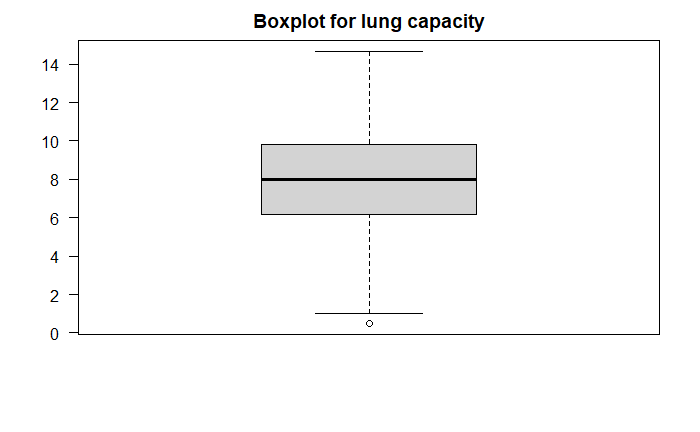

```r
boxplot(data1$LungCap, las=1, main= "Boxplot for lung capacity")
```

From the above boxplot one outlier can be seen. but it can be difficult to read the exact value of the outlier in a boxplot. Therefore a statistical method for finding outliers is needed. By using the quantile() function I can find find the 25th and 75th percentile, and by using the IQR() function I can see the difference between the 75th and 25th percentiles.

```r
# Lung capacity
Q_lung <- quantile(data1$LungCap, probs = c(0.25, 0.75), na.rm = FALSE)
iqr_lung <- IQR(data1$LungCap)
# Age
Q_age <- quantile(data1$Age, probs = c(0.25, 0.75), na.rm = FALSE)
iqr_age <- IQR(data1$Age)
# Height in meter
Q_heightMeter <- quantile(data1$HeightMeter, probs = c(0.25, 0.75), na.rm = FALSE)
iqr_heightMeter <- IQR(data1$HeightMeter)
```

From the above values I can find the cut-off ranges beyond which all data points are outliers.

```r
# Lung capacity
up_lung <-  Q_lung[2]+1.5*iqr_lung # Upper Range
low_lung<- Q_lung[1]-1.5*iqr_lung # Lower Range

# Age
up_age <-  Q_age[2]+1.5*iqr_age # Upper Range
low_age<- Q_age[1]-1.5*iqr_age # Lower Range

# Height in meter
up_heightMeter <-  Q_heightMeter[2]+1.5*iqr_heightMeter # Upper Range
low_heightMeter<- Q_heightMeter[1]-1.5*iqr_heightMeter # Lower Range
```

By using the subset() function I can extract the data between the lower and upper, leaving out the outliers.

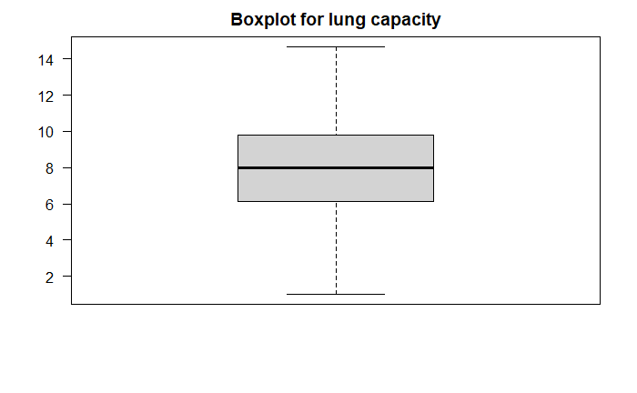

When looking at the updated dataset (data2) it has 1 less observation than the old dataset (data1) which means that I only had 1 outlier.

```r
str(data2)
```

```
'data.frame':   724 obs. of  7 variables:
 $ LungCap    : num  6.47 10.12 9.55 11.12 4.8 ...
 $ Age        : int  6 18 16 14 5 11 8 11 15 11 ...
 $ Height     : num  62.1 74.7 69.7 71 56.9 58.7 63.3 70.4 70.5 59.2 ...
 $ Smoke      : chr  "no" "yes" "no" "no" ...
 $ Gender     : chr  "male" "female" "female" "male" ...
 $ Caesarean  : chr  "no" "no" "yes" "no" ...
 $ HeightMeter: num  1.58 1.9 1.77 1.8 1.45 ...
```

### Correlation matrix and visualization

In the following I will compute a correlation matrix and visualize it with a heat map.

A heat map relates the numeric value from -1 to 1 into a color code where red represents a value of 1 and blue represents a value of -1. 0 indicates a non-correlation. To make the heat map a bit easier to read I have rounded the numerical value to two decimal numbers.

```r
numVar <- data2 %>% select(LungCap, Age, HeightMeter)
cor(numVar)
```

```
              LungCap       Age HeightMeter
LungCap     1.0000000 0.8181640   0.9121143
Age         0.8181640 1.0000000   0.8348995
HeightMeter 0.9121143 0.8348995   1.0000000
```

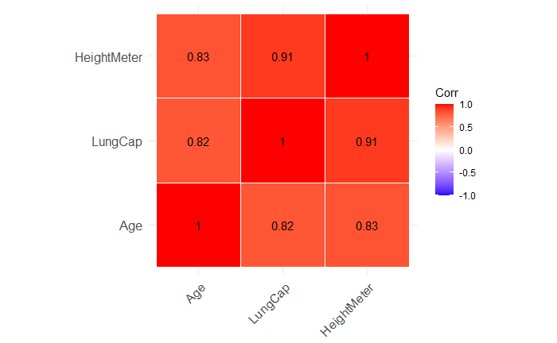

```r
corMatrix <- round(cor(numVar),2)
p.mat<-cor_pmat(numVar)
ggcorrplot(corMatrix,outline.col = "white",  hc.order = TRUE,type = "full",lab = TRUE,p.mat = p.mat)
```

From the correlation matrix and the heat map there seems to be a very strong correlation between lung capacity and height in meter since the Pearson’s correlation coefficient is 0.91. There is a strong correlation between age and lung capacity (0.82 Pearson’s correlation coefficient) as well as between age and height in meter (0.83 Pearson’s correlation coefficient). There is a perfect correlation between a variable and itself but that should be excluded and not be looked into.  
The lung capacity must be the dependent variable, depending on both age and height in meter.

## Scatterplot - dependent variable vs. independent variable

From the above correlation matrix I know that lung capacity is the dependent variable, where age and height in meter is the independent variables. In the following I will create scatterplots for respectively lung capacity vs. age, and lung capacity vs. height in meter.

**Lung capacity vs. age**

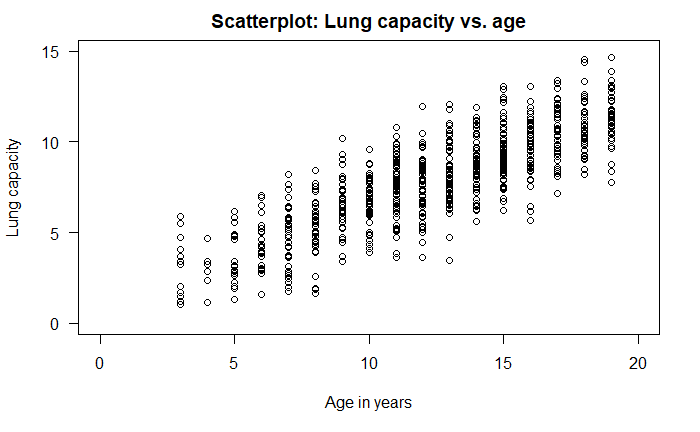

From the scatterplot I can see a strong relationship between age and lung capacity. The higher the age value the higher the lung capacity value. The two variables has a positive association. I can also observe a linear relationship since the points clusters along a straight (wide) line. The scatterplot shows homoscedasticity since all the random variables have the same finite variance. From the scatterplot it is visible that the age variable is discrete since all the points forms a vertical “line”.

**Lung capacity vs. height in meter**

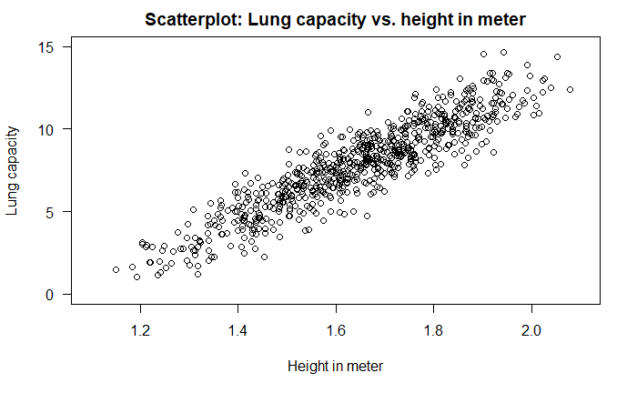

The scatterplots shows a strong relationship between lung capacity and height in meter. It is easy to see that when the value for height in meter increases the lung capacity increases as well. I can see a positive linear relationship between the two variables. The scatterplot is in a homoscedastic form. I can see that both variables are continuous since the points in the plot is not in a vertical or horizontal “line”.

## Linear regression model

In the following I will look into a linear regression model and visualize it with a scatter plot with a line.  
I have chosen lung capacity vs. height in meter, since it has the highest correlation coefficient value.

```r
cor(data2$LungCap,data2$HeightMeter)
```

```
[1] 0.9121143
```

```r
mod <- lm(data2$LungCap ~ data2$HeightMeter)
summary(mod)
```

```
Call:
lm(formula = data2$LungCap ~ data2$HeightMeter)

Residuals:
    Min      1Q  Median      3Q     Max
-3.3653 -0.7001 -0.0060  0.7681  3.3001

Coefficients:
                  Estimate Std. Error t value Pr(>|t|)
(Intercept)       -13.9263     0.3669  -37.96   <2e-16 ***
data2$HeightMeter  13.2335     0.2213   59.79   <2e-16 ***
---
Signif. codes:  0 ‘***’ 0.001 ‘**’ 0.01 ‘*’ 0.05 ‘.’ 0.1 ‘ ’ 1

Residual standard error: 1.087 on 722 degrees of freedom
Multiple R-squared:  0.832, Adjusted R-squared:  0.8317
F-statistic:  3574 on 1 and 722 DF,  p-value: < 2.2e-16
```

```r
mod$coefficients
```

```
      (Intercept) data2$HeightMeter
        -13.92629          13.23349
```

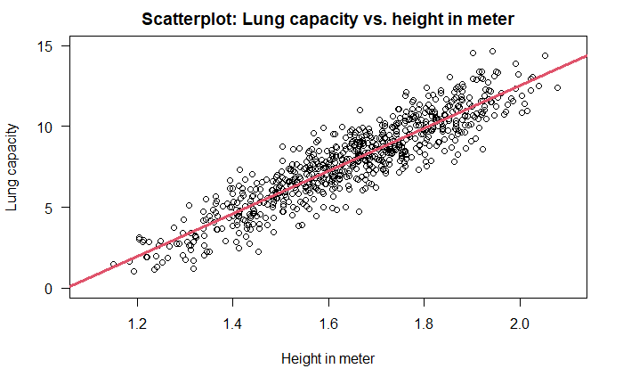

```r
plot(data2$HeightMeter, data2$LungCap, main ="Scatterplot: Lung capacity vs. height in meter", ylab = "Lung capacity", xlab = "Height in meter", las=1, xlim=c(1.1,2.1), ylim=c(0,15))
abline(mod, col=2, lwd=3)
```

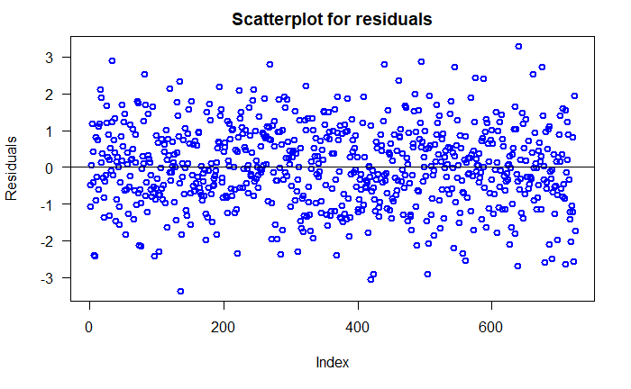

```r
plot(mod$residuals, col="blue", lwd=2, ylab="Residuals", las=1, main = "Scatterplot for residuals")
abline(h=0)
```

In the summary the residuals (errors) are shown, e.g. the residual value for median is -0.0060. The estimate for the intercept is -13.9263 and it’s standard error is 0.3669. The regression coefficient is the average change in the dependent variable (lung capacity) for a 1-unit change in the independent variable (height in meter). It is the slope of the regression line. For height in meter the estimate is 13.2335 and the standard error is 0.2213. The residual standard error is 1.087 which is a measure of a variation of observations around the regression line. This is the same as the square root of the mean squared error. The residual standard error tells how far observed lung capacity are from the predicted or fitted lung capacity. The multiple R-squared values (0.832) means that approx. 83 % of variation of lung capacity can be explained by this model.  
I can see that the height in meter is the cause of the lung capacity. Both of the variables is continuous and have a strong positive linear relationship. The red line (the least squared regression line) is the prediction of the lung capacity based on the height in meter. All the points are the actual data values. The distance from a point to the line is the error called residual, since it is the difference between the actual data point and the predicted value. The line passes through the mean of both variables (lung capacity and height in meter).  
The scatterplot for the residuals shows a random pattern.

## Regression with multiple variables

In the following I will look into regression with multiple variables. I will use lung capacity as the dependent variable and age and height in meter as the independent variables to fit my linear regression model.

```r
model1 <- lm(data2$LungCap ~ data2$Age + data2$HeightMeter)
summary(model1)
```

```
Call:
lm(formula = data2$LungCap ~ data2$Age + data2$HeightMeter)

Residuals:
    Min      1Q  Median      3Q     Max
-3.4101 -0.7042 -0.0092  0.7111  3.1756

Coefficients:
                   Estimate Std. Error t value Pr(>|t|)
(Intercept)       -11.72674    0.47545 -24.665  < 2e-16 ***
data2$Age           0.12409    0.01782   6.964 7.48e-12 ***
data2$HeightMeter  10.96872    0.38955  28.158  < 2e-16 ***
---
Signif. codes:  0 ‘***’ 0.001 ‘**’ 0.01 ‘*’ 0.05 ‘.’ 0.1 ‘ ’ 1

Residual standard error: 1.053 on 721 degrees of freedom
Multiple R-squared:  0.8425,    Adjusted R-squared:  0.8421
F-statistic:  1929 on 2 and 721 DF,  p-value: < 2.2e-16
```

```r
cor(data2$Age, data2$HeightMeter, method = "pearson")
```

```
[1] 0.8348995
```

```r
confint(model1, conf.level=0.95)
```

```
                         2.5 %      97.5 %
(Intercept)       -12.66016395 -10.7933154
data2$Age           0.08910293   0.1590719
data2$HeightMeter  10.20394027  11.7335008
```

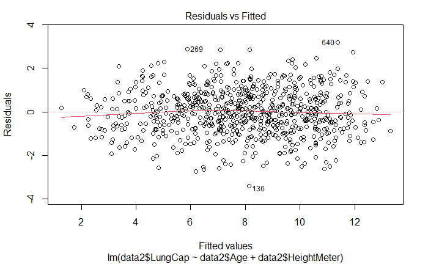

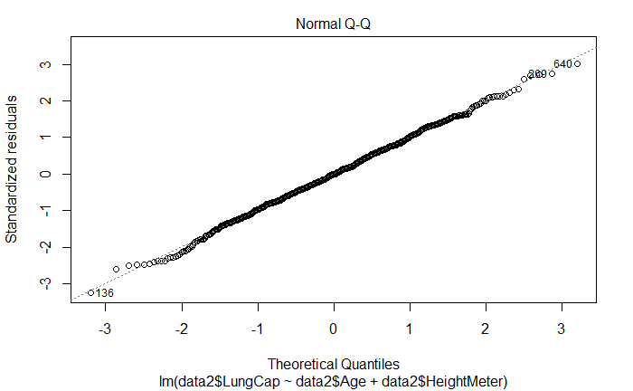

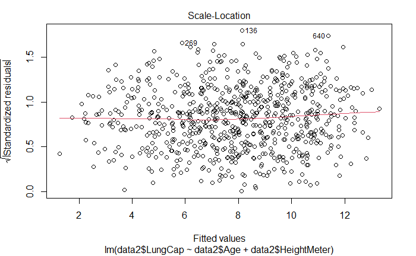

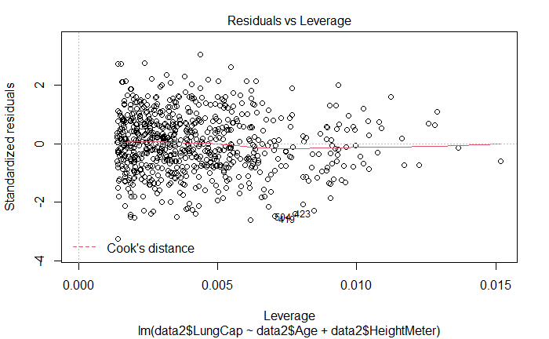

```r
plot(model1)
```

From the summary I can see that the R-squared is 0.8425 which means that approx. 84 % of variation in lung capacity can be explained by this model using age and height in meter. The residual standard error is 1.053 on 721 degrees of freedom. This gives me an idea of how far observed lung capacity (Y values) are form the predicted or fitted lung capacity (the Y-hats). The Intercept of -11.72674 is the estimated mean Y (lung capacity) value when all X-values (age and height in meter) are zero. In other words it is the estimated mean lung capacity for a person with age and height in meter of zero. The value for age estimated is 0.12409. This is the effect of age on lung capacity adjusting or controlling for height in meter. In other words an increase of 1 year in age is associated with an increase of 0.12409 in lung capacity adjusting or controlling for height in meter. The slope for height in meter is 10.96872. This is the estimated effect of height in meter on lung capacity adjusting for age.

The Pearson’s correlation between age and height in meter is 0.8348995 so the two variables are very highly correlated. The collinearity between age and height in meter means that I should not directly interpret the slope (e.g. age), as the effect of age on lung capacity adjusting for height in meter. The high correlation between age and height in meter suggests that these two effects are somewhat bounded together.

The estimated slope for age is 0.12409 or 95 % confident that the true slope is between 0.08910293 and 0.1590719. The estimated slope for height in meter is 10.96872 or 95 % confident that the true slope is between 10.20394027 and 11.7335008.

To check the regression diagnostics for this model with two independent variables I’ll look at the plot for residuals vs. fitted. The relationship between lung capacity and age and height in meter is approx. linear. The variation looks constant. The lung capacity given age and height in meter is approx. normal which can been seen on the Normal Q-Q plot.

If I wanted to fit a model with all the possible X-variables that would be age, height in meter, smoke, gender and caesarean, this could be done so.

```r
model2 <- lm(data2$LungCap ~ data2$Age + data2$HeightMeter + data2$Smoke + data2$Gender + data2$Caesarean)
summary(model2)
```

```
Call:
lm(formula = data2$LungCap ~ data2$Age + data2$HeightMeter +
    data2$Smoke + data2$Gender + data2$Caesarean)

Residuals:
    Min      1Q  Median      3Q     Max
-3.3409 -0.7164  0.0410  0.7014  3.0080

Coefficients:
                    Estimate Std. Error t value Pr(>|t|)
(Intercept)        -11.31501    0.46995 -24.077  < 2e-16 ***
data2$Age            0.15814    0.01801   8.783  < 2e-16 ***
data2$HeightMeter   10.41363    0.39534  26.341  < 2e-16 ***
data2$Smokeyes      -0.60922    0.12570  -4.847 1.54e-06 ***
data2$Gendermale     0.37962    0.07956   4.771 2.22e-06 ***
data2$Caesareanyes  -0.20042    0.09079  -2.208   0.0276 *
---
Signif. codes:  0 ‘***’ 0.001 ‘**’ 0.01 ‘*’ 0.05 ‘.’ 0.1 ‘ ’ 1

Residual standard error: 1.018 on 718 degrees of freedom
Multiple R-squared:  0.8535,    Adjusted R-squared:  0.8525
F-statistic: 836.9 on 5 and 718 DF,  p-value: < 2.2e-16
```

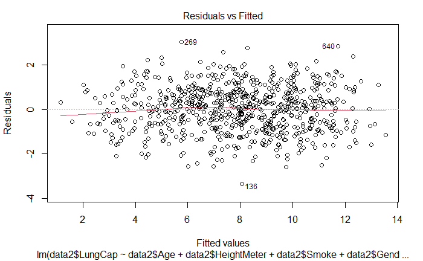

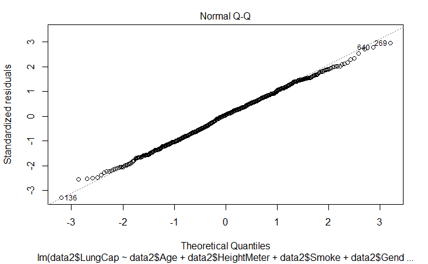

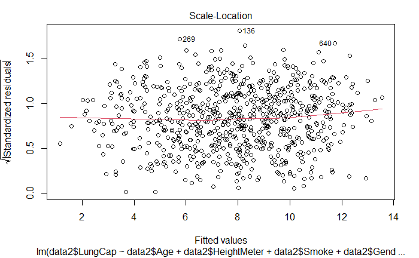

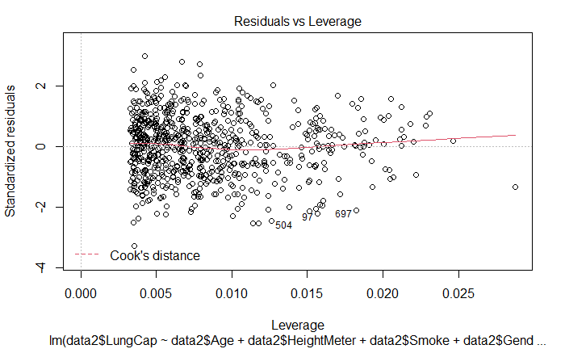

```r
plot(model2)
```

The two models is close to each other but the multiple R-squared is higher for the model with all the X-variables. Also the residual standard error value is lower for the model with all the X-values. This makes good sense since a model provided with more data points should be able to produce a more correct estimate.

# Stage 5 - Training and testing regression model

In the following I will first split my data set into a training set and testing set. I will train my regression models on the training set and then I will test my models on the test set, and evaluate my models for how well they are to predict unknown (future) values.

## Splitting the data set

In the following I will split my data set into a training- and testing set. The training set is used for training the model for predicting values and the testing set is used to test how well the model actually predicts the actual values in the testing set. It is worth to understand that the values in the testing set has not been shown to the model before.  
I am splitting my data set randomly into the training set which will consist of 80 % of the original data set and the last 20 % will be the testing set. It’s important to never ever train the models on the testing data set since it will skew the results and introduce bias into the results.  
First I will create random numbers uniformly distributed between 0-1 for each observation in the data set. The random numbers will be used to reorder my dataset which is saved as a new dataset. To be able to reproduce this random outcome I have set the seed.

```r
set.seed(123)
r <- runif(nrow(data2))
data2r <- data2[order(r), ]
train <- data2r[1:580, ]
test <- data2r[581:724, ]
str(train)
```

```
'data.frame':   580 obs. of  7 variables:
 $ LungCap    : num  8.43 7.83 7.17 8.7 8.82 ...
 $ Age        : int  16 13 17 14 16 8 10 18 9 16 ...
 $ Height     : num  70.5 71 68.8 73.1 71.3 58.4 59.7 68.6 62.4 74.3 ...
 $ Smoke      : chr  "yes" "no" "no" "no" ...
 $ Gender     : chr  "male" "female" "male" "male" ...
 $ Caesarean  : chr  "no" "no" "yes" "yes" ...
 $ HeightMeter: num  1.79 1.8 1.75 1.86 1.81 ...
```

```r
str(test)
```

```
'data.frame':   144 obs. of  7 variables:
 $ LungCap    : num  3.9 9.68 8.43 9.2 5.38 ...
 $ Age        : int  10 12 12 14 11 10 10 5 11 12 ...
 $ Height     : num  58 70.9 69.2 68.7 59.3 65.4 63.2 48.9 63 60.3 ...
 $ Smoke      : chr  "yes" "no" "no" "no" ...
 $ Gender     : chr  "female" "male" "male" "female" ...
 $ Caesarean  : chr  "no" "no" "no" "yes" ...
 $ HeightMeter: num  1.47 1.8 1.76 1.74 1.51 ...
```

```r
#split = sample.split(data2$LungCap, SplitRatio = 0.8)
#training_set = subset(data2, split == TRUE)
#test_set = subset(data2, split == FALSE)
```

The training set contains 580 observations and the test set contains 144 observations.

## Training the model

In the following I will train different regression models on the training set. I will at first train a model with one parameter and thereafter two models with multiple parameters.

```r
cor(train$LungCap,train$HeightMeter)
```

```
[1] 0.9099666
```

```r
fit_model1 <- lm(LungCap~Age, data = train)
summary(fit_model1)
```

```
Call:
lm(formula = LungCap ~ Age, data = train)

Residuals:
    Min      1Q  Median      3Q     Max
-4.7840 -0.9950 -0.0175  0.9738  4.2590

Coefficients:
            Estimate Std. Error t value Pr(>|t|)
(Intercept)  1.17515    0.20435   5.751 1.44e-08 ***
Age          0.54299    0.01576  34.458  < 2e-16 ***
---
Signif. codes:  0 ‘***’ 0.001 ‘**’ 0.01 ‘*’ 0.05 ‘.’ 0.1 ‘ ’ 1

Residual standard error: 1.515 on 578 degrees of freedom
Multiple R-squared:  0.6726,    Adjusted R-squared:  0.672
F-statistic:  1187 on 1 and 578 DF,  p-value: < 2.2e-16
```

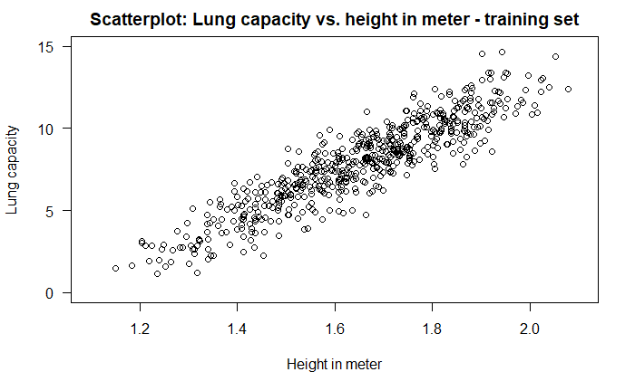

```r
plot(train$HeightMeter, train$LungCap, main ="Scatterplot: Lung capacity vs. height in meter - training set", ylab = "Lung capacity", xlab = "Height in meter", las=1, xlim=c(1.1,2.1), ylim=c(0,15))
```

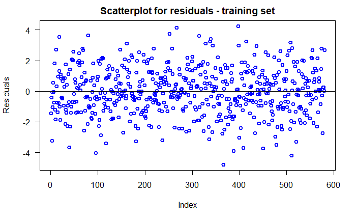

```r
plot(fit_model1$residuals, col="blue", lwd=2, ylab="Residuals", las=1, main = "Scatterplot for residuals - training set")
abline(h=0)
```